# Assignment 2 Data Wrangling

Yaniv Bronshtein

02/07/2021

## Import the libraries

```r
library(tidyverse)
library(gapminder)
```

# 1. Download the dataset on restaurant inspection in csv format from

# https://data.cityofnewyork.us/Health/DOHMH-New-York-City-Restaurant-Inspection-Results/43nn-# pn8j (Links to an external site.)

# and convert it to a data frame.

**read data from csv remove leading and trailing White space**

```r
res_inspec_results <- read_csv(
  "DOHMH_New_York_City_Restaurant_Inspection_Results.csv",
  trim_ws = TRUE)
```

**Convert data read from file to data frame**

```r
df <- as.data.frame(res_inspec_results)
```

## (1a) Form a new data frame restricted to restaurants in Queens with cuisine

## to “Pizza”. [Hint: Use str_detect() in the library stringr.

## Examples of usage of str_detect() can be found here:

## https://stringr.tidyverse.org/reference/str_detect.html]

**Filter df by specifying the BORO field as Queens and using str_detect()** **applied in conjunction with fixed() to ascertain that only the rows in the** **original data frame relating to Pizza in the borough Queens are left are** **left**

```r
queens_pizza <- filter(df, BORO == "Queens",
                         str_detect(`CUISINE DESCRIPTION`,
                                    fixed("Pizza", ignore_case = TRUE)))
```

## 1b). What are the 5 most commonly names inspected restaurants

## (use the variable “DBA”) in the data frame? (queens_pizza)

** Perform the following steps 1. Group the queens_pizza data frame by the DBA field 2. Pipe the result of step 1 to summarize which will return a new data frame** **with just the frequency and the DBA field** **3. Pipe the result of step 2 to the ungroup() function** **4. Pipe the result of step 3 to the arrange() function to sort the frequency** **in descending order** **5. Pipe the result of step 4 to the head() function which is passed the** **constant 5 to display only the first 5 rows of the data frame** **6. Store the result of steps 1 through 5 in the variable common_names**

```r
common_names <- queens_pizza %>% group_by(DBA) %>% summarise(n=n()) %>%
  ungroup() %>% arrange(-n)%>%head(5)
```

**Plot the results in a bar graph**

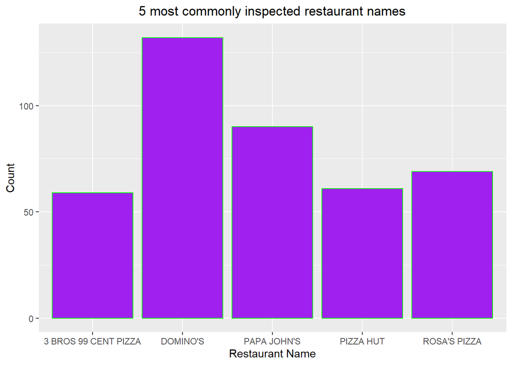

```r
ggplot(data = common_names,
       mapping = aes(x = DBA, y = n)) +
  geom_bar(stat = 'identity', color = "green", fill="purple") +
  labs(
    title = "5 most commonly inspected restaurant names",
    x = "Restaurant Name",
    y = "Count"
  ) +
  theme(plot.title = element_text(hjust = 0.5))
```

*Based on the data in the graph, the 5 most inspected restaurants are DOMINOS’* *PAPA JOHN’S, Rosa’s Pizza, PIZZA HUT, AND 3 BROS 99 CENT PIZZA*

##1c). On what dates has queens pizza parlor “SUSANO’S PIZZERIA & RESTAURANT” ## been inspected? **Filter queens_pizza to match the exact restaurant name. NOTE:** **we cannot use str_detect() because that would mean including restaurants** **such as SUSANO’S PIZZERIA & RESTAURANT I**

```r
queens_pizza_susanos <- filter(queens_pizza,DBA=="SUSANO'S PIZZERIA & RESTAURANT")
```

**Next, we make sure to call distinct() to get rid of duplicate dates. We** **only need the INSPECTION DATE column**

```r
dates_inspected <- distinct(queens_pizza_susanos["INSPECTION DATE"])
dates_inspected
```

```
##    INSPECTION DATE
## 1       09/25/2018
## 2       07/31/2019
## 3       03/15/2018
## 4       01/08/2020
## 5       03/14/2019
## 6       04/13/2018
## 7       12/09/2019
## 8       09/11/2018
## 9       03/01/2017
## 10      03/25/2019
## 11      08/14/2019
```

# 2. The file “gapminder_2007_gini.tsv” is in the “Assignments” folder under the files menu of # the course website; it is a subset of the 2007 Gapminder data merged with recent Gini

# coefficient data (https://en.wikipedia.org/wiki/Gini_coefficient

## 2a). Create a plot to compare the distributions (e.g., central tendency, dispersion) of the ## Gini coefficient in different continents. [Hint: Use using geom_boxplot(). Details and

## examples are available here: https://ggplot2.tidyverse.org/reference/geom_boxplot.html]

**Read in the data from the tab separated vector file, trimming white space**

```r
gapminder_data <- read_tsv("gapminder_2007_gini.tsv", trim_ws = TRUE)
```

**Convert the data read from the file to a data frame**

```r
gap_df <- as.data.frame(gapminder_data)
```

**Create the box plot of distribution by continent**

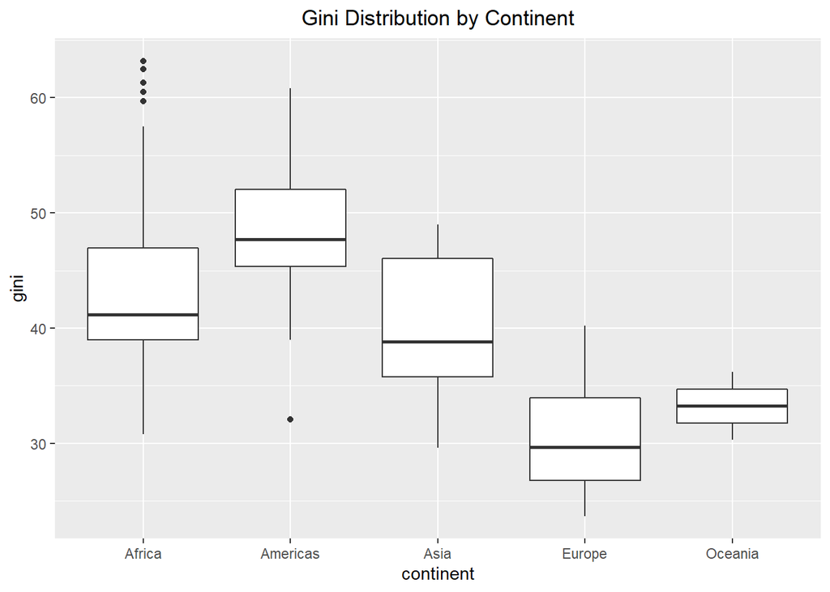

```r
ggplot(data = gap_df, mapping = aes(x = continent, y = gini)) +
  geom_boxplot() +
  labs(
    title = "Gini Distribution by Continent"
  ) +
  theme(plot.title = element_text(hjust = 0.5))
```

## 2b) Does the Gini coefficient appear to have any impact on the life

## expectancy in 2007? Explain your answer using a plot,

## classified by continents

```r
gini_vs_life_exp <- gap_df %>% filter(year == 2007)  %>% group_by(continent)  %>%
  summarise(continent, gini, lifeExp)
```

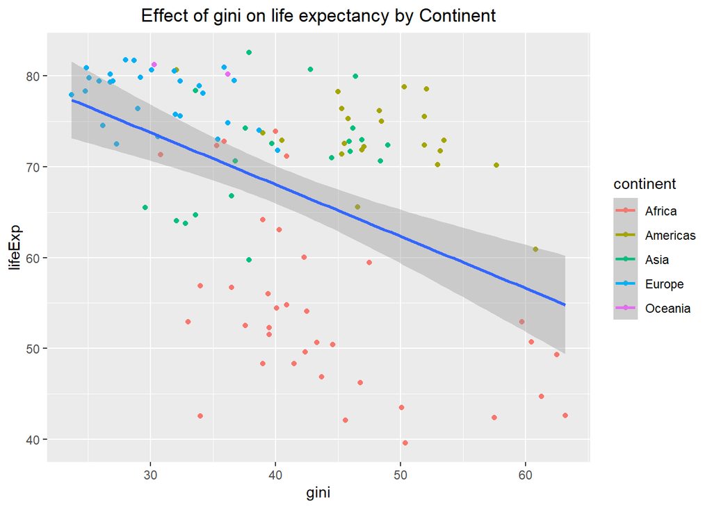

```r
ggplot(data = gini_vs_life_exp, mapping = aes(x = gini, y = lifeExp, color = continent)) +
  geom_point() +
  geom_smooth(method = "lm", mapping = aes(group = 1)) +

  labs(
    title = "Effect of gini on life expectancy by Continent"
  ) +
  theme(plot.title = element_text(hjust = 0.5))
```

*The graph above demonstrates a trend that countries with low gini such as* *Europe and Oceania have much higher life expectancy than Africa which falls* *below the linear regression line*

# (3) Using the original gapminder data frame, please generate a data frame

# with a new variable called gdp by multiplying the population size by the gdp

# per capita. To make those large numbers more understandable, please form an

# new variable called gdp_ratio equal to the gdp divided by the gdp of the

# United States in 2007.

# Find the mean gdp_ratio by continent and year, and then plot the mean

# gdp_ratio over time, distinguishing the continents.

# Please use both points and lines for the plot

**Create a data frame to store the imported data from the R package gapminder**

```r
df2 <- gapminder
```

**Call the dplyr function mutate() to create a calculated column in df2** **to store the gdp**

```r
df2 <- dplyr::mutate(df2, gdp = pop * gdpPercap)
```

**To avoid writing extra code, extract the 2007 gap data on the United States**

```r
us_2007_df <- gap_df %>% filter(country=="United States")
```

**Calculate the gdp manually from the single row by multiply the gdp per capita** **by the population at the time**

```r
us_gdp_2007 <- us_2007_df["gdpPercap"] * us_2007_df["pop"]
```

**Convert the result to a double value and store in the variable denom**

```r
denom <- as.numeric(us_gdp_2007)
```

**Create another calculated column in df2 by calling mutate() on the calculation** **gdp / denom**

```r
df2 <- dplyr::mutate(df2, gdp_ratio = gdp / denom )
```

**1. Pipe df2 to the function group_by() to group by continent and year** **2. Pipe the result of step 1 to the summarise() function which returns** **a data frame with 3 columns: the continents, the year the mean of the gdp ratio** **3. Save the results in the variable q3_info

```r
q3_info <- df2 %>% group_by(continent, year)  %>%
  summarise(continent, year, mean_gdp_ratios = mean(gdp_ratio))
```

**Create the plot of all the data**

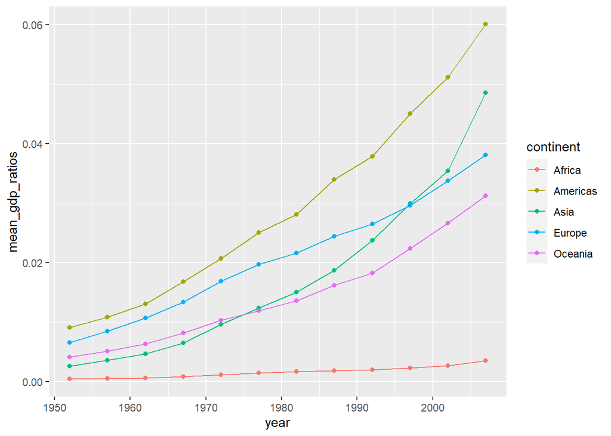

```r
ggplot(data = q3_info, mapping = aes(x = year, y = mean_gdp_ratios, color = continent)) +
  geom_point() +
  geom_line()
```